# ProsperLoan Data Exploration

## by Maxwell Ofoegbu

## Preliminary Wrangling

> This document explores a dataset containing prosperLoan and attributes for approximately 114000 enteries.

The first paragraph of a reprinted Editors Note of a February 13, 2006 BusinessWeek article (found online) By Robert Hof reads as follows: E-Loan co-founder Chris Larsen’s online marketplace matches lenders and borrowers. Banks and “payday” outfits alike will be watching closely. A decade ago, when Chris Larsen co-founded online loan broker E-Loan, he purposely took aim at traditional mortgage lenders, many of which he thought deceived borrowers and charged too much. Now, he intends to shake up a whole new swath of the financial services business. With Prosper Marketplace, a San Francisco startup he launched Feb. 13, (2006). Larsen aims to carve out a new business — this time by doing a number on check-cashing “payday” lenders that charge usurious interest rates. Some of the most interesting things about this idea are that you, the borrower, actually decide what interest rate you are willing to pay, even though you will be told what the standard interest rate is. It is on the basis of the interest rate you offer, among other things, that willing lenders can make informed decisions. This agrees with the unimodal frequency distribution of BorrowerRate shown below with a centre around 0.2. The distribution appears to be slightly in equilibrum however, one can still see that the Borrower’s Rate below the 0.2 mark is more significant than that above the centre.

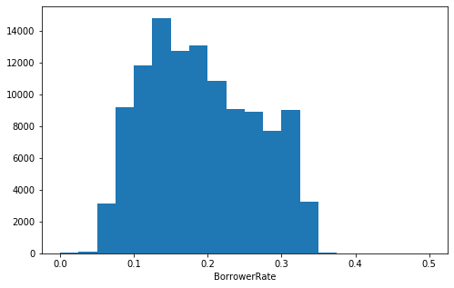

```python
# start with a standard-scaled plot
binsize = .025
bins = np.arange(0, df['BorrowerRate'].max()+binsize, binsize)

plt.figure(figsize=[8, 5])
plt.hist(data = df, x = 'BorrowerRate', bins = bins)
plt.xlabel('BorrowerRate')
plt.show()
```

As can be seen below, the lender's yield is predominantly on the left side of the distribution, in line with: “Larsen's aim to carve out a new business — this time by doing a number on check-cashing “payday” lenders that charge usurious interest rates.“

However, the fact that this distribution for LenderYield is partly right skewed with a peak half way between 0.1 and .2 and a larger portion of the distribution lying toward that left while on the far right are possibly very higher values may suggest the presence of outliers, that is, unusually high lender yield contrary to Larsen's proposed intention and therefore calls for further investigation.

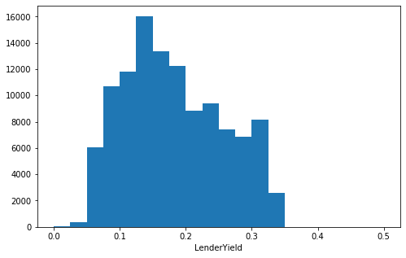

```python
# start with a standard-scaled plot
binsize = .025
bins = np.arange(0, df['LenderYield'].max()+binsize, binsize)

plt.figure(figsize=[8, 5])
plt.hist(data = df, x = 'LenderYield', bins = bins)
plt.xlabel('LenderYield')
plt.show()
```

This idea of Larsen is a bold one — so bold that it’s certain to draw naysayers who may wonder why anyone would lend to people they don’t know. So far, only one other company, Zopa, currently operating only in Britain, has tried something like it, according to what analysts say.

So you may want to ask: “what is/are the risk associated with this innovation?”

Well you are not alone, according to Asaf Buchner a financial services analyst with JupiterResearch, he too at first was skeptical, but now, he thinks the notion could have legs if it follows the same virtuous cycle as eBay, which flourished as buyers flocked to where the sellers were and vice-versa.

when you look at the distribution below, it shows you at a quick glance what the risk factor has been so far. This right skewed distribution shows that the losses so far have been very small, lying mainly toward the left. So this may be a pointer to safety for both lenders and borrowers.

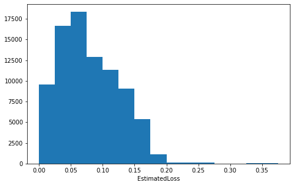

```python
# start with a standard-scaled plot
binsize = .025
bins = np.arange(0, df['EstimatedLoss'].max()+binsize, binsize)

plt.figure(figsize=[8, 5])
plt.hist(data = df, x = 'EstimatedLoss', bins = bins)
plt.xlabel('EstimatedLoss')
plt.show()
```

Larsen essentially hopes to create an eBay style loan marketplace known as ProsperLoan whose job is to match people who need small loans, but can’t get them from traditional banks, with willing lenders.

As seen in the distribution of the so called LoanOriginalAmount, it is clear that this Loan system known as Prosper is limited as to the extent of loan she could give to borrowers at any specific time.

The initial plot of the LoanOriginalAmount shows some immediate points of attention. you would notice sudden spikes and some other very high figures in the far right. This worth taking a bit of time to identify these outliers because they can influence the true result in a distribution.

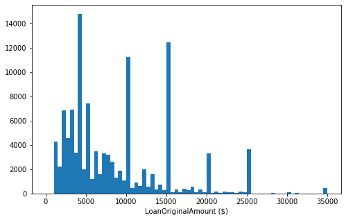

```python
# start with a standard-scaled plot
binsize = 500
bins = np.arange(0, df['LoanOriginalAmount'].max()+binsize, binsize)

plt.figure(figsize=[8, 5])
plt.hist(data = df, x = 'LoanOriginalAmount', bins = bins)
plt.xlabel('LoanOriginalAmount ($)')
plt.show()
```

The distribution below also known as MonthlyLoanPayment shows us the distribution of what Borrowers could get as loan on a given month. One may expect that the more the amount paid montly the more the Borrower'rate or interest rate.

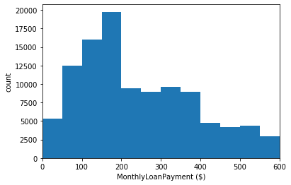

```python
bins =  np.arange(0, df['MonthlyLoanPayment'].max()+50, 50)
plt.hist(data =df, x='MonthlyLoanPayment', bins=bins)
plt.xlim((0,600));
plt.xlabel('MonthlyLoanPayment ($)')
plt.ylabel('count')
```

**Let’s now take a look at some of the categorical features in the dataset**

To further abate your fears, Larsen’s idea is such that no one lender takes the full responsibility of meeting the demand of any one borrower but that lenders can offer up to $50 and above. So this is why the distribution below shows that investors or lenders are mainly contributing very small amount individually.

So, basically People who want to loan money bid in increments starting at $50, usually just for a portion of the loan, to reduce risk. One of the most interesting things about this loan system is that even though borrowers are told what the standard interest rate is, yet they are the ones who actually decide what interest rate they are willingly to pay and it is on that basis that lenders bid for such loans, however, in addition to deciding the interest rate one is willing to pay for a given loan, one is also required to provide credit grades and other criteria. so what we see is a low interest rate being favored by many lenders who will individually contribute small portions of the entire loan thus the distribution below.

Can you now relate to the previoue distribution on EstimatedLoss?

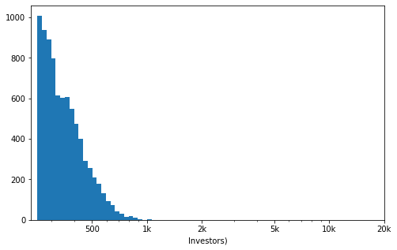

```python
# there's a long tail in the distribution, so let's put it on a log scale instead
log_binsize = 0.025
bins = 10 ** np.arange(2.4, np.log10(df['Investors'].max())+log_binsize, log_binsize)

plt.figure(figsize=[8, 5])
plt.hist(data = df, x = 'Investors', bins = bins)
plt.xscale('log')
plt.xticks([500, 1e3, 2e3, 5e3, 1e4, 2e4], [500, '1k', '2k', '5k', '10k', '20k'])
plt.xlabel('Investors)')
plt.show()
```

The notion is not just to provide a new way for individuals to get small loans. It could also turn anyone with a little money into a banker. Potentially, lenders can earn an annualized 6%-and-up in monthly interest payments from a range of borrowers, providing an addition to stocks, bonds, real estate and the like. “People who have money can invest directly in other people and diversify their investments.

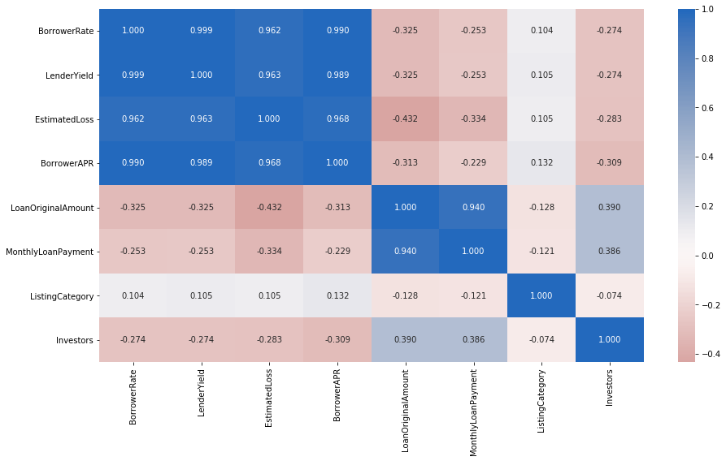

```python
# correlation plot
plt.figure(figsize = [15, 8])
sb.heatmap(df_new[numeric_vars].corr(), annot = True, fmt = '.3f',
           cmap = 'vlag_r', center = 0)
plt.show()
```

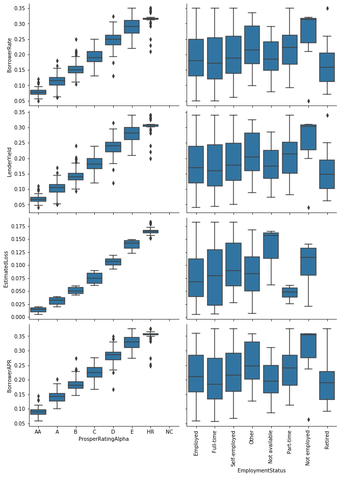

```python
# plot matrix of numeric features against categorical features.
# can use a larger sample since there are fewer plots and they're simpler in nature.

samples = np.random.choice(df_new.shape[0], 2000, replace = False)
df_new_samp = df_new.loc[samples,:]

def boxgrid(x, y, **kwargs):
    """ Quick hack for creating box plots with seaborn's PairGrid. """
    default_color = sb.color_palette()[0]
    sb.boxplot(x, y, color = default_color)

plt.figure(figsize = [20, 15])
g = sb.PairGrid(data = df_new_samp, y_vars = ['BorrowerRate', 'LenderYield', 'EstimatedLoss','BorrowerAPR'], x_vars = categoric_vars_new1,
                size = 3, aspect = 1.5)
g.map(boxgrid)
plt.xticks(rotation=90)
plt.show();
```

Here we see an interesting correlation between BorrowerRate and income range that as one’s income range increase the corresponding borrowerRate decreases

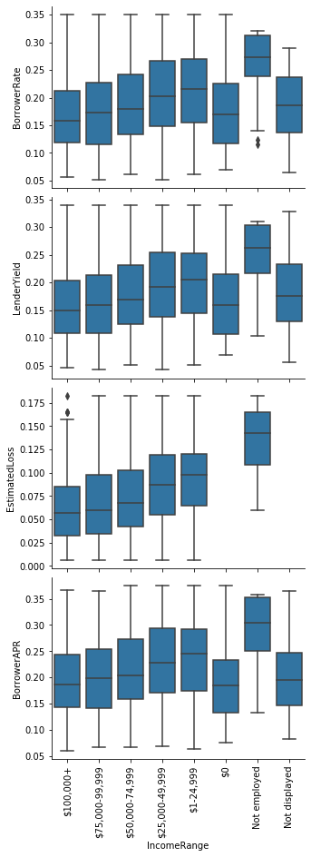

```python
# plot matrix of numeric features against categorical features.
# can use a larger sample since there are fewer plots and they're simpler in nature.

samples = np.random.choice(df_new.shape[0], 2000, replace = False)
df_new_samp = df_new.loc[samples,:]

def boxgrid(x, y, **kwargs):
    """ Quick hack for creating box plots with seaborn's PairGrid. """
    default_color = sb.color_palette()[0]
    sb.boxplot(x, y, color = default_color)

plt.figure(figsize = [50, 15])
g = sb.PairGrid(data = df_new_samp, y_vars = ['BorrowerRate', 'LenderYield', 'EstimatedLoss','BorrowerAPR'], x_vars = categoric_vars_new2,
                size = 3, aspect = 1.5)
g.map(boxgrid)
plt.xticks(rotation=90)
plt.show();
```

When the income range was measured against the BorrowersRate in one of the boxplots it was observed that the BorrowerRate decreases with a rise in income range and increases with a drop in income range. However, here we are noticing the very opposite and this is interesting but not expected because at this point one could simply conclude that ProsperLoan is just one of those profit making ventures out there!

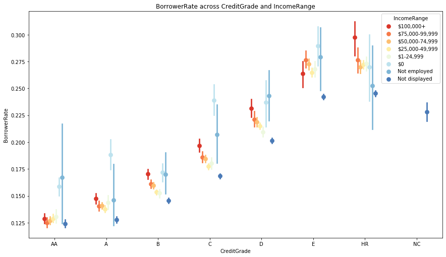

```python
fig = plt.figure(figsize = [14.7,8.27])
ax = sb.pointplot(data = df_1c, x = 'CreditGrade', y = 'BorrowerRate', hue = 'IncomeRange',
           palette = 'RdYlBu', linestyles = '', dodge = 0.4)
plt.title('BorrowerRate across CreditGrade and IncomeRange')
plt.ylabel('BorrowerRate')

plt.show();
```